# Exercícios — Regressão Logística (R)

11 dezembro 2025

# Exercício 1 — Sobrevivência no Titanic (modelo simples com treino/teste)

Use o conjunto de dados `titanic_train` do package **titanic**, contendo variáveis como `Survived`, `Pclass`, `Sex`, `Age` e `Fare`.

```r
library(titanic)
library(dplyr)

dados_titanic <- titanic_train %>%
  select(Survived, Pclass, Sex, Age, Fare) %>%
  na.omit()

dados_titanic$Sex <- factor(dados_titanic$Sex, levels = c("male", "female"))
```

1. Separe os dados em treino (80%) e teste (20%). Explique porque não se deve avaliar o desempenho do modelo nos mesmos dados usados para o ajustar.

```r
n_titanic <- nrow(dados_titanic)

idx_titanic <- sample(seq_len(n_titanic), size = 0.8 * n_titanic)

treino_titanic <- dados_titanic[idx_titanic,]
teste_titanic <- dados_titanic[-idx_titanic,]
```

Se ajustarmos o modelo e avaliarmos o desempenho (accuracy, sensibilidade, especificidade, AUC) nos mesmos dados:

- o modelo foi “treinado” para se adaptar àquele conjunto,
- tende a sobreajustar (overfitting),
- as métricas serão otimistas: medem quão bem o modelo se ajusta aos dados vistos, não quão bem generaliza para novos passageiros. Ao usar:
- dados de treino para ajustar
- dados de teste para avaliar Obtemos uma estimativa mais realista do desempenho em dados futuros.
2. Ajuste, **apenas nos dados de treino**, o modelo:

$$\operatorname{logit}\Big(
P(\text{Survived}=1 \mid \text{Pclass}, \text{Sex}, \text{Age},
\text{Fare})
\Big)
=
\beta_0
+ \beta_1\,\text{Pclass}
+ \beta_2\,\text{Sex}
+ \beta_3\,\text{Age}
+ \beta_4\,\text{Fare}.$$

Interprete: - o sinal de $\beta_1$ (classe), - o sinal e significância de $\beta_2$ (sexo).

```r
modelo_titanic <- glm(
  Survived ~ Pclass + Sex + Age + Fare,
  data = treino_titanic,
  family = binomial
)
```

3. Usando o **conjunto de teste**, calcule as probabilidades previstas $\hat p_i$.  
   Com threshold $t = 0.5$, construa a matriz de confusão e calcule:
   - accuracy,
   - sensibilidade (TPR),
   - especificidade (TNR).

```r
prob_teste_titanic <- predict(
  modelo_titanic,
  newdata = teste_titanic,
  type = "response"
)

prev_titanic <- ifelse(prob_teste_titanic >= 0.5, 1, 0)

matriz_conf_titanic <- table(
  Observado = teste_titanic$Survived,
  Previsto = prev_titanic
)

TP <- matriz_conf_titanic["1","1"]
TN <- matriz_conf_titanic["0","0"]
FP <- matriz_conf_titanic["0","1"]
FN <- matriz_conf_titanic["1","0"]

accuracy_titanic <- (TP + TN) / sum(matriz_conf_titanic)
sens_titanic <- TP / (TP + FN)
espec_titanic <- TN / (TN + FP)

accuracy_titanic
```

```
## [1] 0.8251748
```

```r
sens_titanic
```

```
## [1] 0.734375
```

```r
espec_titanic
```

```
## [1] 0.8987342
```

> Interpretação típica: Accuracy → proporção global de classificações corretas. Sensibilidade → entre os que sobreviveram, que fração o modelo identificou como “sobrevive”? Especificidade → entre os que não sobreviveram, que fração o modelo identificou corretamente como “não sobrevive”?
4. Com a package `pROC`, obtenha a **curva ROC** e a **AUC**.  
   Interprete a AUC.

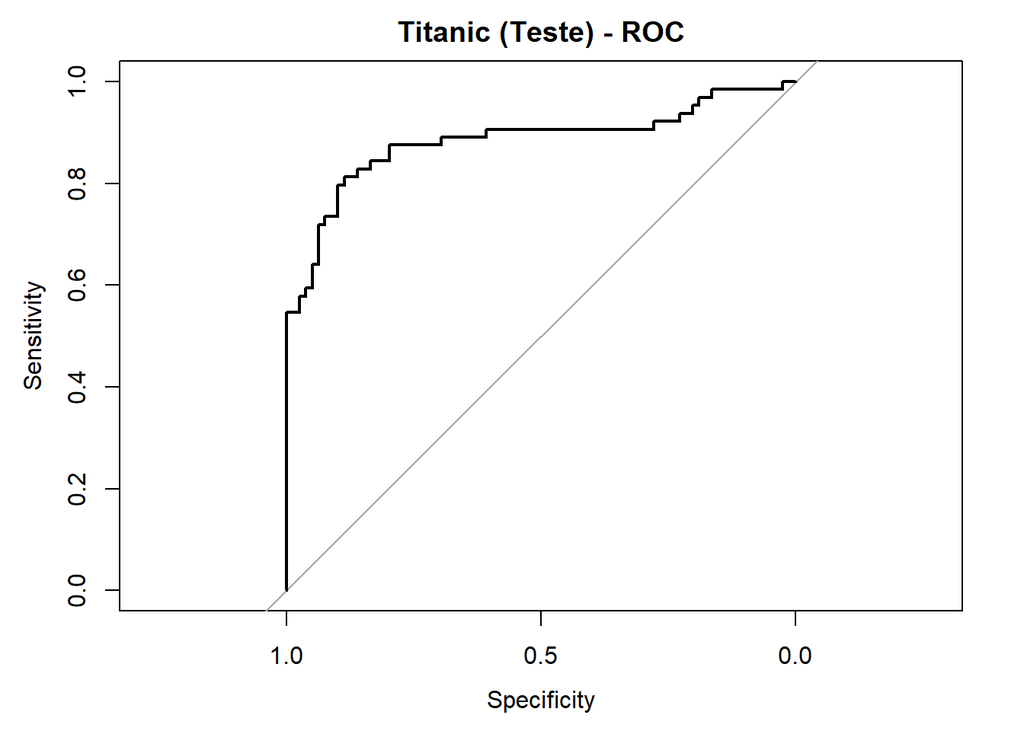

```r
library(pROC)

roc_titanic <- roc(
  response = teste_titanic$Survived,
  predictor = prob_teste_titanic
)

plot(roc_titanic, main = "Titanic (Teste) - ROC")
```

```r
auc(roc_titanic)
```

```
## Area under the curve: 0.8833
```

> A AUC pode ser interpretada como a probabilidade de o modelo atribuir uma probabilidade mais alta de sobrevivência a um passageiro que de facto sobreviveu do que a um passageiro que não sobreviveu, escolhidos ao acaso.

# Exercício 2 — Crédito ao consumo (`Default`, ISLR2)

```r
library(ISLR2)
dados_default <- Default
```

Considere modelar a probabilidade de **incumprimento** (default = “Yes”).

1. Crie $Y = 1$ se `default="Yes"`, $Y=0$ caso contrário.  
   Explique por que a regressão logística é adequada (e a regressão linear não).

```r
dados_default$Y <- ifelse(dados_default$default == "Yes", 1, 0)
```

Por que regressão logística em vez de linear?

> A resposta (Y) é binária (0/1). A regressão linear pode prever valores fora de [0,1] e não respeita a estrutura de probabilidade. A regressão logística modela:
> $$logit(P(Y=1∣X))=β0+⋯$$
> e garante que 0≤P(Y=1∣X)≤1. A função de verosimilhança é adequada a dados binários (modelo Bernoulli/Binomial).
2. Divida os dados em **treino (60%)** e **teste (40%)**.  
   Compare a proporção de incumpridores nos dois conjuntos.

```r
n_default <- nrow(dados_default)
idx_default <- sample(seq_len(n_default), 0.6 * n_default)

treino_default <- dados_default[idx_default,]
teste_default <- dados_default[-idx_default,]

promp_teste <- mean(teste_default$Y)
promp_treino <- mean(treino_default$Y)
```

3. Ajuste o modelo:

$$\operatorname{logit}\Big(
P(Y=1 \mid \text{balance}, \text{income}, \text{student})
\Big)
=
\beta_0
+ \beta_1\,\text{balance}
+ \beta_2\,\text{income}
+ \beta_3\,\text{student}.$$

Interprete: - o sinal de $\beta_1$ (saldo), - o efeito de ser estudante ($\beta_3$), - o significado de $\exp(\beta_1)$ e $\exp(\beta_3)$ como *odds ratios*.

```r
modelo_default <- glm(
  Y ~ balance + income + student,
  data = treino_default,
  family = binomial
)

summary(modelo_default)
```

```
##
## Call:
## glm(formula = Y ~ balance + income + student, family = binomial,
##     data = treino_default)
##
## Coefficients:
##               Estimate Std. Error z value Pr(>|z|)
## (Intercept) -1.055e+01  6.175e-01 -17.088   <2e-16 ***
## balance      5.584e-03  2.893e-04  19.300   <2e-16 ***
## income      -7.345e-07  1.048e-05  -0.070   0.9441
## studentYes  -6.033e-01  3.028e-01  -1.992   0.0463 *
## ---
## Signif. codes:  0 '***' 0.001 '**' 0.01 '*' 0.05 '.' 0.1 ' ' 1
##
## (Dispersion parameter for binomial family taken to be 1)
##
##     Null deviance: 1733.49  on 5999  degrees of freedom
## Residual deviance:  932.89  on 5996  degrees of freedom
## AIC: 940.89
##
## Number of Fisher Scoring iterations: 8
```

#### $\beta_1$ (balance)

- Tipicamente, $\hat\beta_1 > 0$ e altamente significativo.
- Interpretação:
  - Quanto maior o **saldo médio** no cartão (`balance`), maiores as **log-odds** de incumprimento.
  - $e^{\hat\beta_1}$ é o fator pela qual as *odds* de incumprimento se multiplicam quando o saldo aumenta uma unidade (por exemplo, 1 dólar, dependendo da unidade usada).

#### $\beta_3$ (student)

Com `student` como factor (`No` de referência e `Yes`):

- Se $\hat\beta_3 > 0$:
  - ser estudante aumenta as log-odds de incumprimento, comparado a não ser estudante, a `balance` e `income` fixos.
- Se $\hat\beta_3 < 0$:
  - ser estudante diminui as log-odds de incumprimento.

Em qualquer dos casos:

- $e^{\hat\beta_3}$ é a **odds ratio** entre estudantes e não estudantes:
  - valor > 1 → estudantes têm maior risco,
  - valor < 1 → estudantes têm menor risco, ajustando para `balance` e `income`.
4. Usando o modelo, calcule previsões no **teste** com threshold $t=0.5$ e obtenha:
   - matriz de confusão,
   - sensibilidade,
   - especificidade.  
     Comente tendo em conta o risco financeiro de falsos negativos.

```r
prob_teste_default <- predict(
  modelo_default,
  newdata = teste_default,
  type = "response"
)

prev_teste_default <- ifelse(prob_teste_default >= 0.5, 1, 0)

matriz_conf_default <- table(
  Observado = teste_default$Y,
  Previsto = prev_teste_default
)

TP <- matriz_conf_default["1","1"]
TN <- matriz_conf_default["0","0"]
FP <- matriz_conf_default["0","1"]
FN <- matriz_conf_default["1","0"]

accuracy_default <- (TP + TN)/sum(matriz_conf_default)
sens_default <- TP / (TP + FN)
espec_default <- TN / (TN + FP)
```

5. Produza a curva ROC, AUC e determine um threshold ótimo pelo **índice de Youden**.  
   Compare o desempenho entre $t=0.5$ e o threshold ótimo.

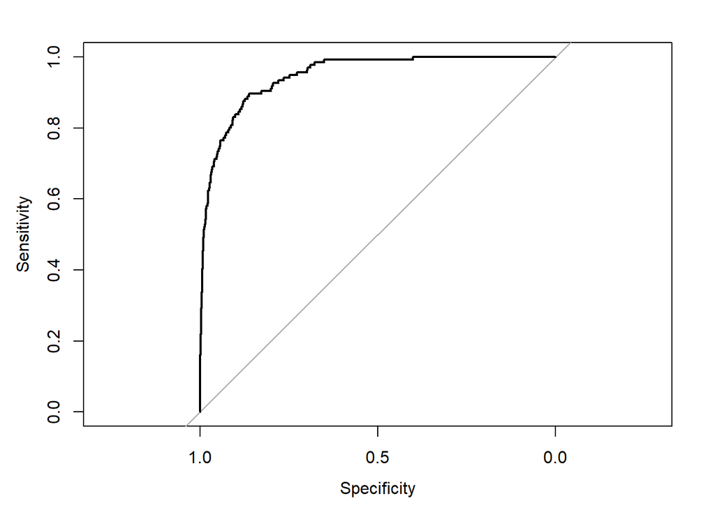

```r
roc_default <- roc(
  response = teste_default$Y,
  predictor = prob_teste_default
)

plot(roc_default)
```

```r
auc(roc_default)
```

```
## Area under the curve: 0.9479
```

```r
coords_default <- coords(
  roc_default,
  x = "best",
  best.method = "youden",
  transpose = TRUE
)

t_default <- coords_default["threshold"]
```

> Comparar: Se o threshold ótimo estiver **abaixo de 0.5**, em geral: **aumenta a sensibilidade** (deteta mais incumpridores), reduz especificidade (mais falsos positivos).

> Em contexto de crédito, isso pode ser aceitável se o custo de conceder empréstimo a um mau pagador for muito maior que o custo de recusar um bom pagador.